# Dnyanai_Surkutwar_Take_Home_test

## Dnyanai Surkutwar: All main observations are in Blue color in the appropriate section.

## Table of content:

[1] Preliminary EDA  
[2] Section I - plotting and calculation functions  
[3] Type of data in the traning data  
[4] Section I- Detailed EDA  
[4.1] Univariate Analysis and Section II  
[4.2] Data Wrangling and Preprocessing, Part I  
[4.3] Data Wrangling and Feature Engineering, Part 2  
[4.4] Hypothesis Testing on Categorical columns  
[4.5] Multivariate Analysis

[5] Prepping data for model  
[6] Section III-KNN Classifier  
[7] KNN Classifier  
[8] Improving dataset issues  
[9] Preparing the test dataset and predicting based on KNN with K=29

```python
from google.colab import drive
drive.mount('/content/drive')
```

# Importing Libraries back

```python
import pandas as pd
import numpy as np
import matplotlib.pyplot as plt
import seaborn as sns

#pd.set_option('display.max_colwidth', None)
#pd.set_option('display.max_rows', None)

# Chi square test
from scipy.stats import chi2_contingency
from scipy.stats import chi2

#Scikit learn model_selection
from sklearn.model_selection import train_test_split

from sklearn.neighbors import KNeighborsClassifier
from sklearn.metrics import accuracy_score,classification_report,plot_confusion_matrix,confusion_matrix,plot_precision_recall_curve,plot_roc_curve

#Import KFold CV
from sklearn.model_selection import cross_val_score
# import GridSearchCV
from sklearn.model_selection import GridSearchCV
```

```python
!pwd
```

```
/content
```

```python
df = pd.read_csv('/content/drive/MyDrive/Colab Notebooks/Noodle.ai/IncomePredictionTrain.txt')
df_test = pd.read_csv('/content/drive/MyDrive/Colab Notebooks/Noodle.ai/IncomePredictionTest[1].txt')
```

# 1. Preliminary EDA: back

```python
df.head()
```

|  | rowid | age | workclass | fnlwgt | education | education_num | marital_status | occupation | relationship | race | sex | capital_gain | capital_loss | hours_per_week | native_country | yearly_income |
| --- | --- | --- | --- | --- | --- | --- | --- | --- | --- | --- | --- | --- | --- | --- | --- | --- |
| 0 | 1 | 38 | Private | 108907 | HS-grad | 9 | Divorced | Craft-repair | Not-in-family | White | Male | 0 | 0 | 40 | ? | <=50K |
| 1 | 3 | 58 | Self-emp-not-inc | 33309 | HS-grad | 9 | Widowed | Farming-fishing | Not-in-family | White | Male | 0 | 0 | 80 | United-States | <=50K |
| 2 | 4 | 62 | Private | 169204 | HS-grad | 9 | Widowed | Craft-repair | Unmarried | White | Male | 0 | 0 | 40 | United-States | <=50K |
| 3 | 5 | 53 | Private | 82646 | Doctorate | 16 | Divorced | Exec-managerial | Not-in-family | White | Female | 0 | 0 | 55 | United-States | >50K |
| 4 | 6 | 40 | Local-gov | 233891 | HS-grad | 9 | Never-married | Adm-clerical | Unmarried | Black | Female | 0 | 0 | 35 | United-States | <=50K |

```python
df.shape
```

```
(26049, 16)
```

```python
df_test.shape
```

```
(6512, 16)
```

```python
for srno, col in enumerate(df.columns):
    print(srno, col)
```

```
0 rowid
1 age
2 workclass
3 fnlwgt
4 education
5 education_num
6 marital_status
7 occupation
8 relationship
9 race
10 sex
11 capital_gain
12 capital_loss
13 hours_per_week
14 native_country
15 yearly_income
```

```python
df.describe()
```

|  | rowid | age | fnlwgt | education_num | capital_gain | capital_loss | hours_per_week |
| --- | --- | --- | --- | --- | --- | --- | --- |
| count | 26049.000000 | 26049.000000 | 2.604900e+04 | 26049.000000 | 26049.000000 | 26049.000000 | 26049.000000 |
| mean | 16271.319590 | 38.589274 | 1.894995e+05 | 10.078199 | 1077.775423 | 85.858190 | 40.439057 |
| std | 9402.676798 | 13.614376 | 1.054885e+05 | 2.577200 | 7403.682592 | 400.481239 | 12.411520 |
| min | 1.000000 | 17.000000 | 1.228500e+04 | 1.000000 | 0.000000 | 0.000000 | 1.000000 |
| 25% | 8141.000000 | 28.000000 | 1.177670e+05 | 9.000000 | 0.000000 | 0.000000 | 40.000000 |
| 50% | 16256.000000 | 37.000000 | 1.780250e+05 | 10.000000 | 0.000000 | 0.000000 | 40.000000 |
| 75% | 24432.000000 | 48.000000 | 2.368050e+05 | 12.000000 | 0.000000 | 0.000000 | 45.000000 |
| max | 32561.000000 | 90.000000 | 1.484705e+06 | 16.000000 | 99999.000000 | 4356.000000 | 99.000000 |

```python
df.info()
```

```
<class 'pandas.core.frame.DataFrame'>
RangeIndex: 26049 entries, 0 to 26048
Data columns (total 16 columns):
 #   Column          Non-Null Count  Dtype
---  ------          --------------  -----
 0   rowid           26049 non-null  int64
 1   age             26049 non-null  int64
 2   workclass       26049 non-null  object
 3   fnlwgt          26049 non-null  int64
 4   education       26049 non-null  object
 5   education_num   26049 non-null  int64
 6   marital_status  26049 non-null  object
 7   occupation      26049 non-null  object
 8   relationship    26049 non-null  object
 9   race            26049 non-null  object
 10  sex             26049 non-null  object
 11  capital_gain    26049 non-null  int64
 12  capital_loss    26049 non-null  int64
 13  hours_per_week  26049 non-null  int64
 14  native_country  26049 non-null  object
 15  yearly_income   26049 non-null  object
dtypes: int64(7), object(9)
memory usage: 3.2+ MB
```

```python
df.isna().sum()
```

```
rowid             0
age               0
workclass         0
fnlwgt            0
education         0
education_num     0
marital_status    0
occupation        0
relationship      0
race              0
sex               0
capital_gain      0
capital_loss      0
hours_per_week    0
native_country    0
yearly_income     0
dtype: int64
```

# 2. All plotting functions and calculation functions: back

### 1) Sns_barplot()

```python
#x = df.workclass.value_counts().index
#y = df.workclass.value_counts().values

def sns_barplot(x,y, tname, xrotation):
    plt.figure(figsize=(10,8))

    splot=sns.barplot(x=x,y=y)

    for p in splot.patches:
        splot.annotate(format(p.get_height(), '.1f'),
                       (p.get_x() + p.get_width() / 2., p.get_height()),
                       ha = 'center', va = 'center',
                       xytext = (0, 9),
                       textcoords = 'offset points')

    splot.set_xticklabels(rotation=xrotation,labels=x)
    plt.title(tname)
    plt.show()
```

### 2) Sns_countplot()

```python
def sns_countplot(x, hue, data, tname, xrotation):
    plt.figure(figsize=(10,8))
    splot = sns.countplot(x=x, hue=hue, data=data)

    plt.xticks(None, None, rotation ='30')
    plt.title(tname)
    for p in splot.patches:
        splot.annotate('{:.1f}'.format(p.get_height()),(p.get_x()+0.1, p.get_height()+50))
    plt.show()
```

### 4) Contingency table and Chi square test functions:

```python
# contingency table
def c_table(x, t):
    ct = pd.crosstab(df[x]\
                  .sample(frac=0.002, replace=True, random_state=1)\
                  ,df[t]\
                  .sample(frac=0.002, replace=True, random_state=1),margins = False)
    return ct

def chi_test(c_t):
    stat, p, dof, expected = chi2_contingency(c_t)
    print('dof=%d' % dof)
    print('p_value', p)
    print(expected)

    # interpret test-statistic:
    prob = 0.95
    critical = chi2.ppf(prob, dof)

    print('probability=%.3f, critical=%.3f, stat=%.3f' % (prob, critical, stat))

    if abs(stat) >= critical:
        print('Dependent (reject H0)')
    else:
        print('Independent (fail to reject H0)')
```

### 3) Count Percentage in a column:

```python
def pct_valcount(col, data):

    return round(df[col].value_counts()/len(data)*100, 2)
```

# 3. Types of classes present in each column: back

#### Columns like rowid, fnlwght, capital_gain, capital_loss can be ignored for now, the focus is more on the categorical columns to understand the data more. These columns may be important but we can look at them later.

```python
columns = ['age', 'workclass', 'education', 'education_num', 'marital_status', 'occupation', 'relationship',
          'race', 'sex', 'hours_per_week', 'native_country']

#for each in columns:
#    print(df[each].value_counts())
```

#### Since, the above output is hard to read, lets invest some time in making these observations more readable and understandable.

# 4. Section 1- Unvariate Analysis, Multivariate Analysis and Hypothesis Testing on categorical columns/features: back

## 4.1. Univariate analysis: back

### 4.1.1. Age

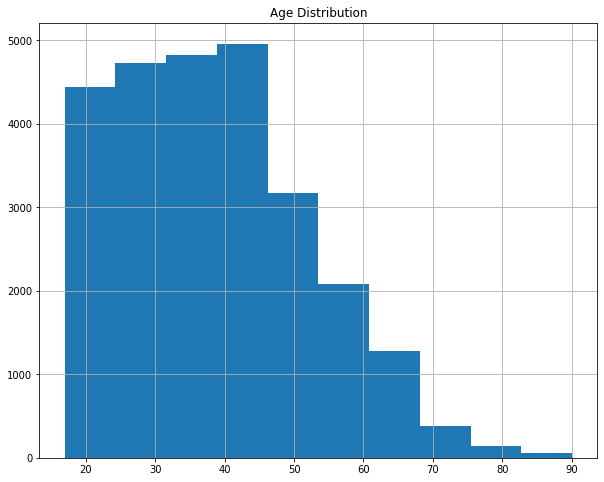

```python
#sns.histplot(df.age)
plt.figure(figsize=(10,8))

df.age.hist()
plt.title('Age Distribution')
plt.show()
```

#### Lets make a new discrete feature "age_range" and drop the "age" column for the dataset:

```python
print('Min age:',df['age'].min())
print('Max age:',df['age'].max())
```

```
Min age: 17
Max age: 90
```

```python
df['age_range'] = pd.cut(df['age'], bins = [15,25,35,45,55,65,75,85,95], \
                         labels = ['15-25','25-35','35-45','45-55', '55-65', '65-75', '75-85', '85-95'])
```

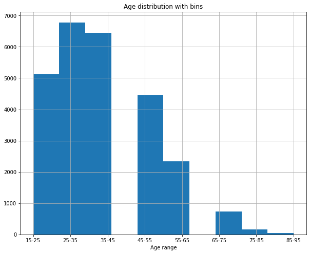

```python
plt.figure(figsize=(10,8))
df.age_range.sort_values().hist()
plt.title('Age distribution with bins')
plt.xlabel('Age range')
plt.show()
```

```python
df.groupby('age_range')['age'].count()
```

```
age_range
15-25    5116
25-35    6782
35-45    6447
45-55    4443
55-65    2342
65-75     727
75-85     154
85-95      38
Name: age, dtype: int64
```

```python
df.age[df.age>65].count()
```

```
919
```

```python
df.head()
```

|  | rowid | age | workclass | fnlwgt | education | education_num | marital_status | occupation | relationship | race | sex | capital_gain | capital_loss | hours_per_week | native_country | yearly_income | age_range |
| --- | --- | --- | --- | --- | --- | --- | --- | --- | --- | --- | --- | --- | --- | --- | --- | --- | --- |
| 0 | 1 | 38 | Private | 108907 | HS-grad | 9 | Divorced | Craft-repair | Not-in-family | White | Male | 0 | 0 | 40 | ? | <=50K | 35-45 |
| 1 | 3 | 58 | Self-emp-not-inc | 33309 | HS-grad | 9 | Widowed | Farming-fishing | Not-in-family | White | Male | 0 | 0 | 80 | United-States | <=50K | 55-65 |
| 2 | 4 | 62 | Private | 169204 | HS-grad | 9 | Widowed | Craft-repair | Unmarried | White | Male | 0 | 0 | 40 | United-States | <=50K | 55-65 |
| 3 | 5 | 53 | Private | 82646 | Doctorate | 16 | Divorced | Exec-managerial | Not-in-family | White | Female | 0 | 0 | 55 | United-States | >50K | 45-55 |
| 4 | 6 | 40 | Local-gov | 233891 | HS-grad | 9 | Never-married | Adm-clerical | Unmarried | Black | Female | 0 | 0 | 35 | United-States | <=50K | 35-45 |

### 4.1.2. Education and Education_num

```python
round(df.groupby('education')['education_num'].value_counts().sort_values(ascending=False)/len(df)*100,2)
```

```
education     education_num
HS-grad       9                32.15
Some-college  10               22.44
Bachelors     13               16.49
Masters       14                5.22
Assoc-voc     11                4.21
11th          7                 3.62
Assoc-acdm    12                3.29
10th          6                 2.86
7th-8th       4                 2.01
Prof-school   15                1.79
9th           5                 1.62
12th          8                 1.32
Doctorate     16                1.28
5th-6th       3                 1.03
1st-4th       2                 0.51
Preschool     1                 0.15
Name: education_num, dtype: float64
```

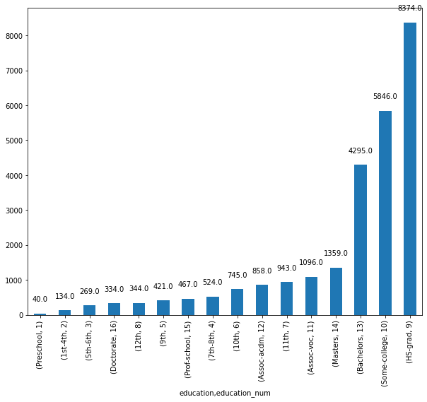

```python
plt.figure(figsize=(10,8))
splot = df.groupby('education')['education_num'].value_counts().sort_values().plot(kind='bar')
for p in splot.patches:
        splot.annotate(format(p.get_height(), '.1f'),
                       (p.get_x() + p.get_width() / 2., p.get_height()),
                       ha = 'center', va = 'center',
                       xytext = (0, 20),
                       textcoords = 'offset points')
plt.show()
```

#### Observations on Education and Education_num column: Most of the employees seems to be High school grads (32.15%) (Maximum - 8374) Majority of the employees have graduated high school (8374), some-college(2yrs or 4yrs (unknown))(\~23%)(5846) and Bachelors \(~17%)(4295)

### 4.1.3. Section #2 Answers: Mean of hours-per-week v/s age_range and median of Education by age_rage

```python
df[['age_range', 'hours_per_week', 'education_num', 'education']].head()
```

|  | age_range | hours_per_week | education_num | education |
| --- | --- | --- | --- | --- |
| 0 | 35-45 | 40 | 9 | HS-grad |
| 1 | 55-65 | 80 | 9 | HS-grad |
| 2 | 55-65 | 40 | 9 | HS-grad |
| 3 | 45-55 | 55 | 16 | Doctorate |
| 4 | 35-45 | 35 | 9 | HS-grad |

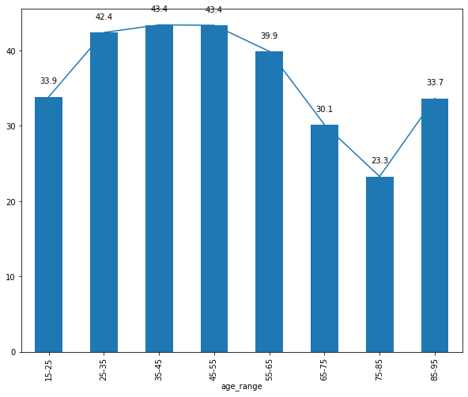

```python
plt.figure(figsize=(10,8))

df.groupby('age_range')['hours_per_week'].mean().plot(kind='line')

splot = df.groupby('age_range')['hours_per_week'].mean().plot(kind='bar')


for p in splot.patches:
        splot.annotate(format(p.get_height(), '.1f'),
                       (p.get_x() + p.get_width() / 2., p.get_height()),
                       ha = 'center', va = 'center',
                       xytext = (0, 20),
                       textcoords = 'offset points')
plt.show()
```

```python
df_sec2 = pd.DataFrame(df.groupby('age_range', as_index=False)\
         [['hours_per_week', 'education_num', 'education']].mean()\
         .sort_values(by= 'hours_per_week',ascending=False)).reset_index(drop=True)
df_sec2
```

|  | age_range | hours_per_week | education_num |
| --- | --- | --- | --- |
| 0 | 35-45 | 43.406546 | 10.544129 |
| 1 | 45-55 | 43.351789 | 10.280666 |
| 2 | 25-35 | 42.397670 | 10.266735 |
| 3 | 55-65 | 39.887703 | 9.555508 |
| 4 | 15-25 | 33.855356 | 9.410281 |
| 5 | 85-95 | 33.657895 | 10.052632 |
| 6 | 65-75 | 30.148556 | 9.517194 |
| 7 | 75-85 | 23.272727 | 9.220779 |

```python
df.education.unique()
```

```
array(['HS-grad', 'Doctorate', 'Bachelors', 'Assoc-acdm', 'Some-college',
       'Assoc-voc', '11th', '7th-8th', '12th', '9th', 'Masters', '10th',
       'Prof-school', 'Preschool', '5th-6th', '1st-4th'], dtype=object)
```

```python
for srno, val in enumerate(df.education.unique(),1):
    print(srno, val)
```

```
1 HS-grad
2 Doctorate
3 Bachelors
4 Assoc-acdm
5 Some-college
6 Assoc-voc
7 11th
8 7th-8th
9 12th
10 9th
11 Masters
12 10th
13 Prof-school
14 Preschool
15 5th-6th
16 1st-4th
```

#### Creating a dictionary to map the education level categories to education_num:

```python
edu_level= {int(val[1]):val[0] for val in df[['education', 'education_num']]\
            .drop_duplicates().sort_values(by='education_num').values}

edu_level
```

```
{1: 'Preschool',
 2: '1st-4th',
 3: '5th-6th',
 4: '7th-8th',
 5: '9th',
 6: '10th',
 7: '11th',
 8: '12th',
 9: 'HS-grad',
 10: 'Some-college',
 11: 'Assoc-voc',
 12: 'Assoc-acdm',
 13: 'Bachelors',
 14: 'Masters',
 15: 'Prof-school',
 16: 'Doctorate'}
```

```python
df_ = pd.DataFrame(df.groupby('age_range', as_index=False).agg(education_num_median = ('education_num', 'median'), \
                                                hours_per_week_mean = ('hours_per_week','mean')))
df_
```

|  | age_range | education_num_median | hours_per_week_mean |
| --- | --- | --- | --- |
| 0 | 15-25 | 10 | 33.855356 |
| 1 | 25-35 | 10 | 42.397670 |
| 2 | 35-45 | 10 | 43.406546 |
| 3 | 45-55 | 10 | 43.351789 |
| 4 | 55-65 | 9 | 39.887703 |
| 5 | 65-75 | 9 | 30.148556 |
| 6 | 75-85 | 9 | 23.272727 |
| 7 | 85-95 | 9 | 33.657895 |

```python
df_.columns
```

```
Index(['age_range', 'education_num_median', 'hours_per_week_mean'], dtype='object')
```

```python
df_.education_num_median = df_.education_num_median.map(edu_level)
```

```python
print('Section #2 answers - \n')
df_
```

```
Section #2 answers -
```

|  | age_range | education_num_median | hours_per_week_mean |
| --- | --- | --- | --- |
| 0 | 15-25 | Some-college | 33.855356 |
| 1 | 25-35 | Some-college | 42.397670 |
| 2 | 35-45 | Some-college | 43.406546 |
| 3 | 45-55 | Some-college | 43.351789 |
| 4 | 55-65 | HS-grad | 39.887703 |
| 5 | 65-75 | HS-grad | 30.148556 |
| 6 | 75-85 | HS-grad | 23.272727 |
| 7 | 85-95 | HS-grad | 33.657895 |

#### Observations on avg working hours per week and median of Education level by age-range: Senior the age, less number of average number of hours per week. Middle-aged adults(25-55) contribute minimum of ~43 hours per week. Young adults(15-25 age range) and Seniors (65+) contribute on an avg, fewer number of hours per week than Middle-aged adults (25-55) The median of education level for age group 15-55 is 10 i.e. Some_college The median of education level for age group 55+ is 9 i.e. HS-grad

### 4.1.4 Section #2 Answers: 3. Calculate the median age for males and females by occupation

```python
df.columns
```

```
Index(['rowid', 'age', 'workclass', 'fnlwgt', 'education', 'education_num',
       'marital_status', 'occupation', 'relationship', 'race', 'sex',
       'capital_gain', 'capital_loss', 'hours_per_week', 'native_country',
       'yearly_income', 'age_range'],
      dtype='object')
```

```python
df_med_age_gender = df.groupby(['occupation','sex'], as_index=False)['age'].median()\
                    .pivot(index= 'occupation', columns = ['sex']).fillna(0)
df_med_age_gender
```

| sex occupation | age Female | age Male |
| --- | --- | --- |
| ? | 29.0 | 47.0 |
| Adm-clerical | 35.0 | 36.0 |
| Armed-Forces | 0.0 | 24.0 |
| Craft-repair | 39.0 | 38.0 |
| Exec-managerial | 39.0 | 43.0 |
| Farming-fishing | 39.0 | 40.0 |
| Handlers-cleaners | 32.0 | 29.0 |
| Machine-op-inspct | 37.0 | 36.0 |
| Other-service | 33.0 | 31.0 |
| Priv-house-serv | 39.5 | 23.0 |
| Prof-specialty | 38.0 | 40.0 |
| Protective-serv | 32.0 | 36.5 |
| Sales | 29.0 | 38.0 |
| Tech-support | 32.0 | 37.0 |
| Transport-moving | 38.0 | 40.0 |

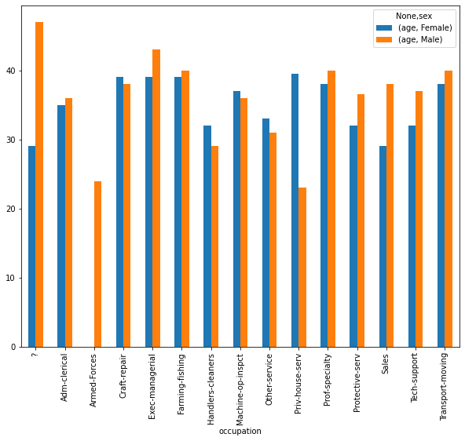

```python
df_med_age_gender.plot(kind='bar', figsize=(10,8))
plt.show()
```

### 4.1.5. Workclass

```python
x = df.workclass.value_counts().index
y = df.workclass.value_counts().values
```

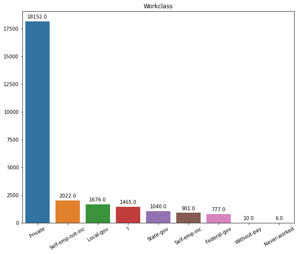

```python
sns_barplot(x,y, 'Workclass', 30)
```

```python
round(df.groupby('workclass')['workclass'].count().sort_values(ascending=False)/len(df)*100,2)
```

```
workclass
Private             69.68
Self-emp-not-inc     7.76
Local-gov            6.43
?                    5.62
State-gov            3.99
Self-emp-inc         3.46
Federal-gov          2.98
Without-pay          0.04
Never-worked         0.02
Name: workclass, dtype: float64
```

### 4.1.6. Fnlwght:

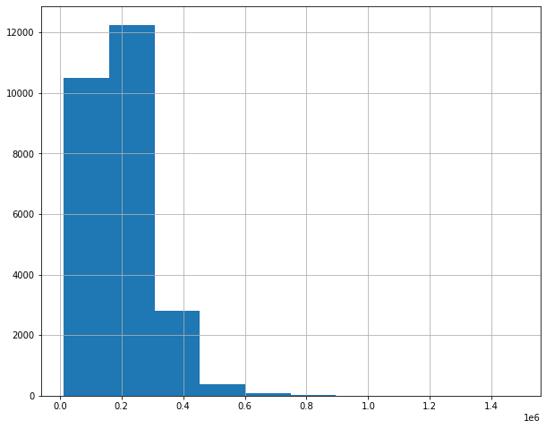

```python
df.fnlwgt.hist(figsize=(10,8))
plt.show()
```

#### Observations: This column seems to correspond to final wght in the data. Seems like we can ignore this column The distribution is right skewed.

### 4.1.7. Marital Status:

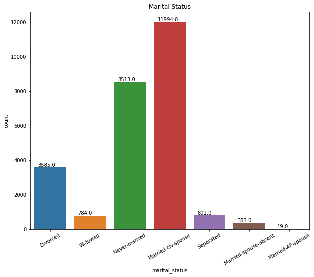

```python
sns_countplot('marital_status', None, df, 'Marital Status', '90')
```

```python
round(df.marital_status.value_counts()/len(df)*100,2)
```

```
Married-civ-spouse       46.04
Never-married            32.68
Divorced                 13.76
Separated                 3.07
Widowed                   3.01
Married-spouse-absent     1.36
Married-AF-spouse         0.07
Name: marital_status, dtype: float64
```

#### Observations: There are 7 unique categories in the marital-status column. married-civ-spouse(46.04%) and Never-married(~33%) are the most dominant categories in the dataset. Married-AF-spouse has minimum number of observations at 19 samples which account for only 0.07% of the total dataset.

```python
df.columns
```

```
Index(['rowid', 'age', 'workclass', 'fnlwgt', 'education', 'education_num',
       'marital_status', 'occupation', 'relationship', 'race', 'sex',
       'capital_gain', 'capital_loss', 'hours_per_week', 'native_country',
       'yearly_income', 'age_range'],
      dtype='object')
```

### 4.1.8. Occupation

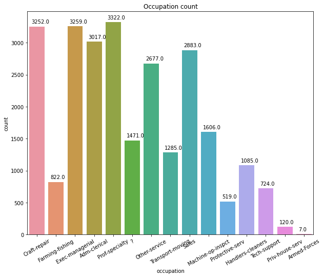

```python
sns_countplot('occupation',None,  df, 'Occupation count', 'vertical')
```

```python
pct_valcount('occupation', df)
```

```
Prof-specialty       12.75
Exec-managerial      12.51
Craft-repair         12.48
Adm-clerical         11.58
Sales                11.07
Other-service        10.28
Machine-op-inspct     6.17
?                     5.65
Transport-moving      4.93
Handlers-cleaners     4.17
Farming-fishing       3.16
Tech-support          2.78
Protective-serv       1.99
Priv-house-serv       0.46
Armed-Forces          0.03
Name: occupation, dtype: float64
```

```python
df.columns
```

```
Index(['rowid', 'age', 'workclass', 'fnlwgt', 'education', 'education_num',
       'marital_status', 'occupation', 'relationship', 'race', 'sex',
       'capital_gain', 'capital_loss', 'hours_per_week', 'native_country',
       'yearly_income', 'age_range'],
      dtype='object')
```

### 4.1.9. Relationship

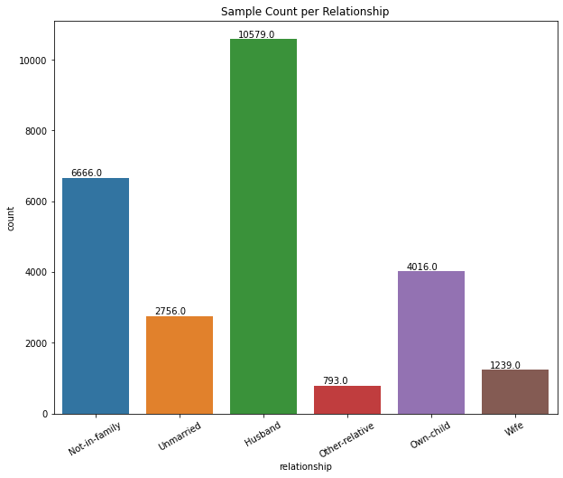

```python
sns_countplot('relationship',None, df, 'Sample Count per Relationship', 'vertical')
```

```python
pct_valcount('relationship', df)
```

```
Husband           40.61
Not-in-family     25.59
Own-child         15.42
Unmarried         10.58
Wife               4.76
Other-relative     3.04
Name: relationship, dtype: float64
```

#### Observations: There are 6 unique categories in the relationship column. Husband has maximum percentage (40.61%) among all categories followed by not-in-family(25.59%)

### 4.1.10. Race:

```python
df.columns
```

```
Index(['rowid', 'age', 'workclass', 'fnlwgt', 'education', 'education_num',
       'marital_status', 'occupation', 'relationship', 'race', 'sex',
       'capital_gain', 'capital_loss', 'hours_per_week', 'native_country',
       'yearly_income', 'age_range'],
      dtype='object')
```

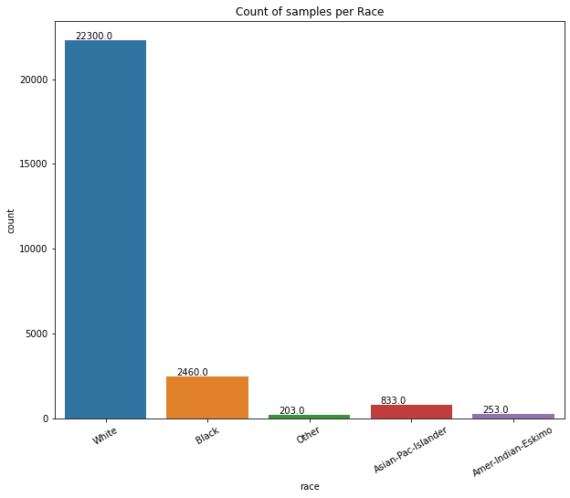

```python
sns_countplot('race',None,df, 'Count of samples per Race', 'vertical')
```

```python
pct_valcount('race', df)
```

```
White                 85.61
Black                  9.44
Asian-Pac-Islander     3.20
Amer-Indian-Eskimo     0.97
Other                  0.78
Name: race, dtype: float64
```

#### Observations: There are 5 unique categories in the race column. White race accounts for almost 86% of the population. The dataset is predominantly "White" with only 9.44% belonging to "Black" race.

### 4.1.11. Sex

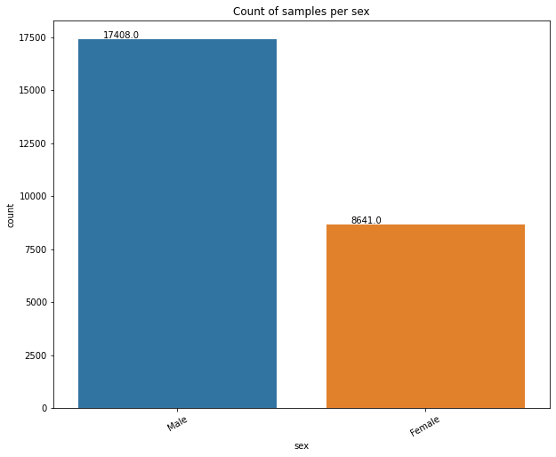

```python
sns_countplot('sex',None, df, 'Count of samples per sex', '30' )
```

```python
pct_valcount('sex', df)
```

```
Male      66.83
Female    33.17
Name: sex, dtype: float64
```

#### Observations: There are 2 unique categories in the sex column. Male sex samples are 33.66% more than female sex samples. This will create a bias towards Male sex.

### 4.1.12. native_country

```python
df.columns
```

```
Index(['rowid', 'age', 'workclass', 'fnlwgt', 'education', 'education_num',
       'marital_status', 'occupation', 'relationship', 'race', 'sex',
       'capital_gain', 'capital_loss', 'hours_per_week', 'native_country',
       'yearly_income', 'age_range'],
      dtype='object')
```

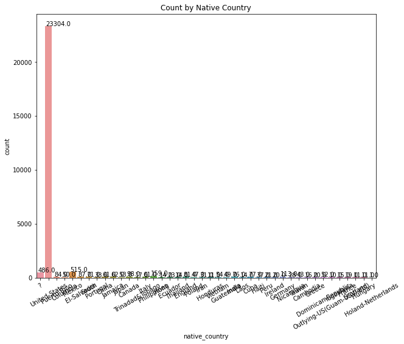

```python
sns_countplot('native_country',None, df, 'Count by Native Country', 'vertical')
```

```python
pct_valcount('native_country', df)
```

```
United-States                 89.46
Mexico                         1.98
?                              1.87
Philippines                    0.61
Germany                        0.43
Canada                         0.38
El-Salvador                    0.33
Puerto-Rico                    0.32
England                        0.31
Cuba                           0.30
India                          0.29
South                          0.27
Jamaica                        0.24
China                          0.23
Italy                          0.23
Vietnam                        0.21
Japan                          0.20
Dominican-Republic             0.20
Columbia                       0.19
Guatemala                      0.19
Poland                         0.18
Taiwan                         0.17
Haiti                          0.14
Portugal                       0.13
Iran                           0.12
Nicaragua                      0.11
Ecuador                        0.09
Peru                           0.08
Greece                         0.08
Ireland                        0.08
France                         0.07
Trinadad&Tobago                0.07
Cambodia                       0.06
Yugoslavia                     0.06
Hong                           0.05
Laos                           0.05
Thailand                       0.05
Honduras                       0.04
Scotland                       0.04
Hungary                        0.04
Outlying-US(Guam-USVI-etc)     0.04
Holand-Netherlands             0.00
Name: native_country, dtype: float64
```

### 4.1.13. Hours_per_week

```python
df.columns
```

```
Index(['rowid', 'age', 'workclass', 'fnlwgt', 'education', 'education_num',
       'marital_status', 'occupation', 'relationship', 'race', 'sex',
       'capital_gain', 'capital_loss', 'hours_per_week', 'native_country',
       'yearly_income', 'age_range'],
      dtype='object')
```

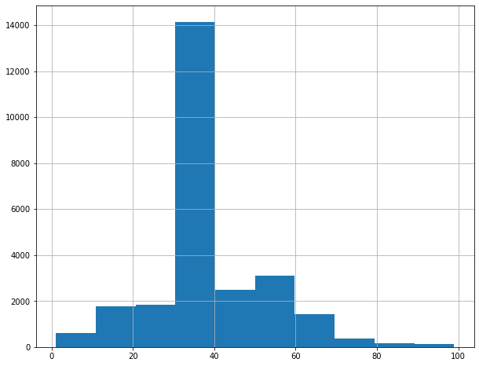

```python
df.hours_per_week.hist(figsize=(10,8))
plt.show()
```

```python
pct_valcount('hours_per_week', df).nlargest(10)
```

```
40    46.64
50     8.63
45     5.54
60     4.60
35     3.92
20     3.78
30     3.49
55     2.17
25     2.05
48     1.62
Name: hours_per_week, dtype: float64
```

```python
pct_valcount('hours_per_week', df).nsmallest(10)
```

```
89    0.00
87    0.00
61    0.00
82    0.00
74    0.00
92    0.00
76    0.01
91    0.01
67    0.01
88    0.01
Name: hours_per_week, dtype: float64
```

#### Observations: ~47% of the employees work 40 hours and we also see that working 40+ hours is also present in the dataset. There are also some people who are working more than 80 hours and some which are working 20 or less hours which is not a normal pattern.

### 4.1.14. Capital_gain

```python
df.columns
```

```
Index(['rowid', 'age', 'workclass', 'fnlwgt', 'education', 'education_num',
       'marital_status', 'occupation', 'relationship', 'race', 'sex',
       'capital_gain', 'capital_loss', 'hours_per_week', 'native_country',
       'yearly_income', 'age_range'],
      dtype='object')
```

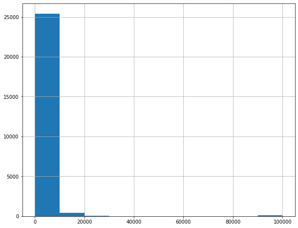

```python
df.capital_gain.hist(figsize=(10,8))
plt.show()
```

#### Observations: As per observation, most values are around 0 and only some gains which are in the range of 10K or 10K+ are present This tells us that maybe the capital gain is made with a condition that if the gains are 10K or 10K+ (a significantly large amount) then it is capital_gain else it is 0.

### 4.1.15. Capital_loss

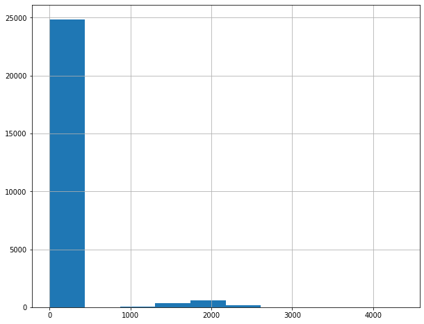

```python
df.capital_loss.hist(figsize=(10,8))
plt.show()
```

#### Observations: This column is similar to capital_gain

#### 4.1.15.1 Is there a relationship between capital_gain and capital_loss?

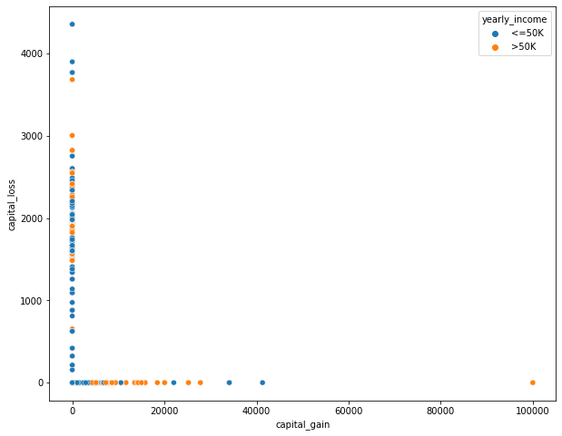

```python
plt.figure(figsize=(10,8))
sns.scatterplot('capital_gain', 'capital_loss', data = df, hue = 'yearly_income')
plt.show()
```

#### Observations: Both capital gain and capital loss can be 0. If capital loss is zero then capital gain can be more than 0 and vice versa. Feature can be extracted from these two column -> Change_in_Capital as (Capital gain - Capital Loss)

### 4.1.16. Yearly_Income (Target Column):

```python
df.columns
```

```
Index(['rowid', 'age', 'workclass', 'fnlwgt', 'education', 'education_num',
       'marital_status', 'occupation', 'relationship', 'race', 'sex',
       'capital_gain', 'capital_loss', 'hours_per_week', 'native_country',
       'yearly_income', 'age_range'],
      dtype='object')
```

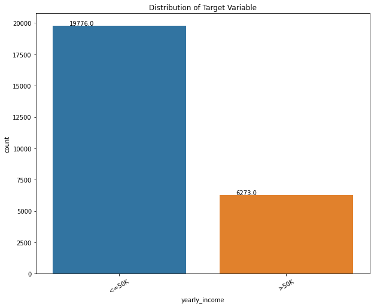

```python
sns_countplot('yearly_income',None,df, 'Distribution of Target Variable', 'horizontal')
```

```python
pct_valcount('yearly_income', df)
```

```
<=50K    75.92
>50K     24.08
Name: yearly_income, dtype: float64
```

#### Observations: This dataset is imbalanced with ~76% of samples belonging to <=50K category n and just 24% under the income group - who earns more than 50k.

## 4.2. Data cleaning/Wrangling and processing (Part1): back

#### It looks like instead of null/Nan/Blanks we have a '?' symbol instead where ever the data is not available, lets check which columns have this '?' symbol in it:

```python
for each in list(df.columns):
    if len(df[each][df[each]== '?']) != 0:
        print('\n',each, '-', df[each].dtype, '\n Num of ?\'s:', len(df[each][df[each]== '?']), \
              '\n Total # of rows:', len(df), \
              '\n Percentage of ?\'s present (%):',round(len(df[each][df[each]== '?'])/len(df)*100,2))
```

```
 workclass - object
 Num of ?'s: 1465
 Total # of rows: 26049
 Percentage of ?'s present (%): 5.62

 occupation - object
 Num of ?'s: 1471
 Total # of rows: 26049
 Percentage of ?'s present (%): 5.65

 native_country - object
 Num of ?'s: 486
 Total # of rows: 26049
 Percentage of ?'s present (%): 1.87
```

#### Lets look at all the columns which have a '?' row value and fill them with the mode of that column:

```python
## First lets replace all the '?' with NaN so that we can use fillna function:
df.replace('?', np.nan, inplace=True)
```

```python
df.head(1)
```

|  | rowid | age | workclass | fnlwgt | education | education_num | marital_status | occupation | relationship | race | sex | capital_gain | capital_loss | hours_per_week | native_country | yearly_income | age_range |
| --- | --- | --- | --- | --- | --- | --- | --- | --- | --- | --- | --- | --- | --- | --- | --- | --- | --- |
| 0 | 1 | 38 | Private | 108907 | HS-grad | 9 | Divorced | Craft-repair | Not-in-family | White | Male | 0 | 0 | 40 | NaN | <=50K | 35-45 |

```python
df.isna().sum()
```

```
rowid                0
age                  0
workclass         1465
fnlwgt               0
education            0
education_num        0
marital_status       0
occupation        1471
relationship         0
race                 0
sex                  0
capital_gain         0
capital_loss         0
hours_per_week       0
native_country     486
yearly_income        0
age_range            0
dtype: int64
```

```python
df.head()
```

|  | rowid | age | workclass | fnlwgt | education | education_num | marital_status | occupation | relationship | race | sex | capital_gain | capital_loss | hours_per_week | native_country | yearly_income | age_range |
| --- | --- | --- | --- | --- | --- | --- | --- | --- | --- | --- | --- | --- | --- | --- | --- | --- | --- |
| 0 | 1 | 38 | Private | 108907 | HS-grad | 9 | Divorced | Craft-repair | Not-in-family | White | Male | 0 | 0 | 40 | NaN | <=50K | 35-45 |
| 1 | 3 | 58 | Self-emp-not-inc | 33309 | HS-grad | 9 | Widowed | Farming-fishing | Not-in-family | White | Male | 0 | 0 | 80 | United-States | <=50K | 55-65 |
| 2 | 4 | 62 | Private | 169204 | HS-grad | 9 | Widowed | Craft-repair | Unmarried | White | Male | 0 | 0 | 40 | United-States | <=50K | 55-65 |
| 3 | 5 | 53 | Private | 82646 | Doctorate | 16 | Divorced | Exec-managerial | Not-in-family | White | Female | 0 | 0 | 55 | United-States | >50K | 45-55 |
| 4 | 6 | 40 | Local-gov | 233891 | HS-grad | 9 | Never-married | Adm-clerical | Unmarried | Black | Female | 0 | 0 | 35 | United-States | <=50K | 35-45 |

```python
for each in list(df.columns):
    if df[each].isna().sum() > 0:
        print(each,df[each].mode()[0])
        df[each].fillna(df[each].mode()[0], inplace=True)
```

```
workclass Private
occupation Prof-specialty
native_country United-States
```

## 4.3 Data Wrangling/Cleaning (Part 2) and Feature Engineering for model: back

#### We understood how each column is in the data, for modelling we can merge some similar looking categories together to decrease the feature space. Also, we need to create a new feature called as Change_in_capital.

```python
df.head()
```

|  | rowid | age | workclass | fnlwgt | education | education_num | marital_status | occupation | relationship | race | sex | capital_gain | capital_loss | hours_per_week | native_country | yearly_income | age_range |
| --- | --- | --- | --- | --- | --- | --- | --- | --- | --- | --- | --- | --- | --- | --- | --- | --- | --- |
| 0 | 1 | 38 | Private | 108907 | HS-grad | 9 | Divorced | Craft-repair | Not-in-family | White | Male | 0 | 0 | 40 | United-States | <=50K | 35-45 |
| 1 | 3 | 58 | Self-emp-not-inc | 33309 | HS-grad | 9 | Widowed | Farming-fishing | Not-in-family | White | Male | 0 | 0 | 80 | United-States | <=50K | 55-65 |
| 2 | 4 | 62 | Private | 169204 | HS-grad | 9 | Widowed | Craft-repair | Unmarried | White | Male | 0 | 0 | 40 | United-States | <=50K | 55-65 |
| 3 | 5 | 53 | Private | 82646 | Doctorate | 16 | Divorced | Exec-managerial | Not-in-family | White | Female | 0 | 0 | 55 | United-States | >50K | 45-55 |
| 4 | 6 | 40 | Local-gov | 233891 | HS-grad | 9 | Never-married | Adm-clerical | Unmarried | Black | Female | 0 | 0 | 35 | United-States | <=50K | 35-45 |

### 4.3.1 Decreasing the number of categories on Education column:

```python
df.education.value_counts()
```

```
HS-grad         8374
Some-college    5846
Bachelors       4295
Masters         1359
Assoc-voc       1096
11th             943
Assoc-acdm       858
10th             745
7th-8th          524
Prof-school      467
9th              421
12th             344
Doctorate        334
5th-6th          269
1st-4th          134
Preschool         40
Name: education, dtype: int64
```

#### Lets club the school grades as school since these just mean that people either just completed primary or secondary school and did not finish high school.

```python
## Making a new column for qualification:
df ['education_level'] = df.education
```

```python
df.education_level.loc[df.education=='Preschool'] = 'School'
df.education_level.loc[df.education=='1st-4th'] = 'School'
df.education_level.loc[df.education=='5th-6th'] = 'School'
df.education_level.loc[df.education=='7th-8th'] = 'School'
df.education_level.loc[df.education=='9th'] = 'School'
df.education_level.loc[df.education=='10th'] = 'School'
df.education_level.loc[df.education=='11th'] = 'School'
df.education_level.loc[df.education=='12th'] = 'School'
```

#### Associate degrees are mostly offered in community colleges, so lets club associate degrees into Associate degrees too.

```python
df.education_level.loc[df.education=='Assoc-voc'] = 'Associates'
df.education_level.loc[df.education=='Assoc-acdm'] = 'Associates'
```

#### Because we do not know how many years "Some-college" degree and "Prof-school" took to call it "Bachelors", we will keep it as it is.

```python
df.groupby('education_level')['education_level'].agg(['count']).sort_values(by=['count'], ascending=False)
```

| education_level | count |
| --- | --- |
| HS-grad | 8374 |
| Some-college | 5846 |
| Bachelors | 4295 |
| School | 3420 |
| Associates | 1954 |
| Masters | 1359 |
| Prof-school | 467 |
| Doctorate | 334 |

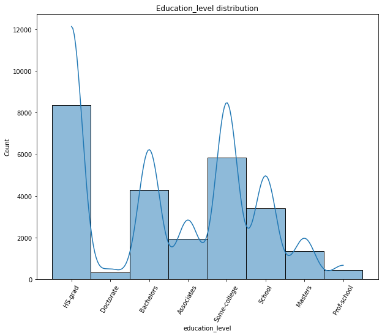

```python
plt.figure(figsize=(10,8))
sns.histplot(x = df.education_level, data = df.education, kde=True)
plt.title('Education_level distribution')
plt.xticks(None, None, rotation=60)
plt.show()
```

### 4.3.2. Native_country column:

```python
df.native_country.unique()
```

```
array(['United-States', 'Puerto-Rico', 'Columbia', 'Mexico',
       'El-Salvador', 'South', 'Portugal', 'China', 'Jamaica', 'Japan',
       'Canada', 'Trinadad&Tobago', 'Italy', 'Philippines', 'Hong',
       'Ecuador', 'Thailand', 'England', 'Poland', 'Iran', 'Honduras',
       'Vietnam', 'Guatemala', 'India', 'Laos', 'Cuba', 'Haiti', 'Peru',
       'Ireland', 'Germany', 'Nicaragua', 'Taiwan', 'Cambodia', 'Greece',
       'Dominican-Republic', 'Outlying-US(Guam-USVI-etc)', 'Yugoslavia',
       'France', 'Scotland', 'Hungary', 'Holand-Netherlands'],
      dtype=object)
```

```python
## Changing the native_country cloumn to binary as almost 91+% data is in the USA:
df['country'] = df.native_country.apply(lambda x: 0 if x != 'United-States' else 1)
```

```python
df.country.value_counts()
```

```
1    23790
0     2259
Name: country, dtype: int64
```

### 4.3.3. Making new feature 'Change_in_Capital':

```python
df['change_capital'] = df['capital_gain'] - df['capital_loss']
```

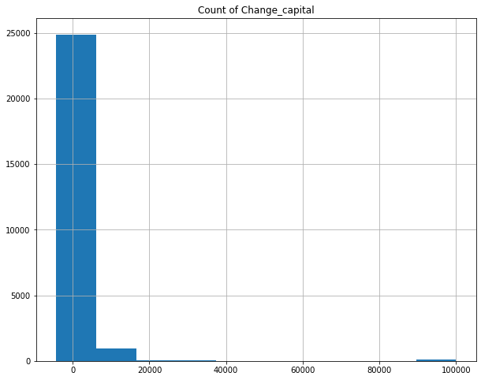

```python
df.change_capital.hist(figsize=(10,8))
plt.title('Count of Change_capital')
plt.show()
```

#### Observation: It is similar to distribution of capital gain and capital loss. Thus, we will replace these two features with one feature called change_capital

### 4.3.4. Finding out Pearson's coefficient between numerical features to yearly_income:

```python
## Following up on what we saw for Capital_gain and capital_loss columns, lets make a new column capital
```

```python
num_cols = df.columns[(df.dtypes == 'int64')|(df.dtypes == 'float')]
num_cols
```

```
Index(['rowid', 'age', 'fnlwgt', 'education_num', 'capital_gain',
       'capital_loss', 'hours_per_week', 'country', 'change_capital'],
      dtype='object')
```

```python
df['target'] = df.yearly_income.apply(lambda x: 1 if x == '>50K' else 0)
```

```python
corr = df[num_cols].corrwith(df['target'])
corr[abs(corr)> 0.05] ##more than the common threshold 0.05 for stating it a significant relationship
```

```
age               0.235175
education_num     0.332754
capital_gain      0.222954
capital_loss      0.150459
hours_per_week    0.228252
change_capital    0.214142
dtype: float64
```

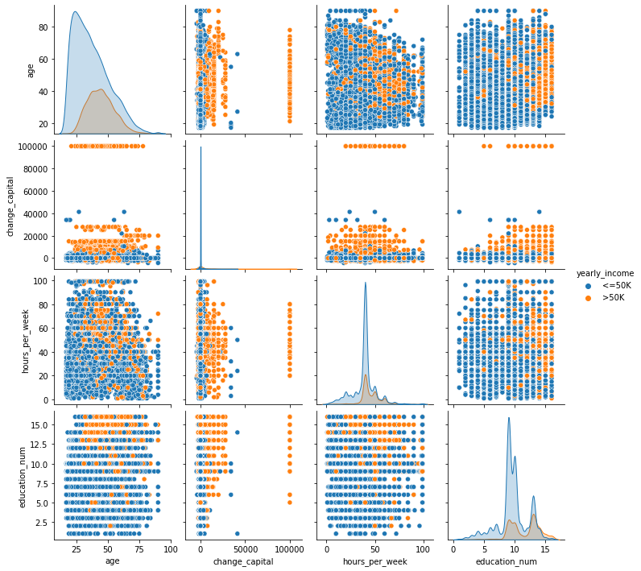

```python
## Lets how the labels of the dataset are in the dataset.
## only looking at those columns who have a significant coefficient above
cols = ['age', 'change_capital', 'hours_per_week', 'education_num', 'yearly_income']
sns.pairplot(df[cols], diag_kind='kde', hue='yearly_income')
plt.show()
```

```python
df.head()
```

|  | rowid | age | workclass | fnlwgt | education | education_num | marital_status | occupation | relationship | race | sex | capital_gain | capital_loss | hours_per_week | native_country | yearly_income | age_range | education_level | country | change_capital | target |
| --- | --- | --- | --- | --- | --- | --- | --- | --- | --- | --- | --- | --- | --- | --- | --- | --- | --- | --- | --- | --- | --- |
| 0 | 1 | 38 | Private | 108907 | HS-grad | 9 | Divorced | Craft-repair | Not-in-family | White | Male | 0 | 0 | 40 | United-States | <=50K | 35-45 | HS-grad | 1 | 0 | 0 |
| 1 | 3 | 58 | Self-emp-not-inc | 33309 | HS-grad | 9 | Widowed | Farming-fishing | Not-in-family | White | Male | 0 | 0 | 80 | United-States | <=50K | 55-65 | HS-grad | 1 | 0 | 0 |
| 2 | 4 | 62 | Private | 169204 | HS-grad | 9 | Widowed | Craft-repair | Unmarried | White | Male | 0 | 0 | 40 | United-States | <=50K | 55-65 | HS-grad | 1 | 0 | 0 |
| 3 | 5 | 53 | Private | 82646 | Doctorate | 16 | Divorced | Exec-managerial | Not-in-family | White | Female | 0 | 0 | 55 | United-States | >50K | 45-55 | Doctorate | 1 | 0 | 1 |
| 4 | 6 | 40 | Local-gov | 233891 | HS-grad | 9 | Never-married | Adm-clerical | Unmarried | Black | Female | 0 | 0 | 35 | United-States | <=50K | 35-45 | HS-grad | 1 | 0 | 0 |

#### Observations on the numerical columns in the data: The target variable seems to be imbalanced as observed above. This poses an issue as the model will train really well on the one class label but it will not generalize enough for learning/detecting all patterns representing income class of >50K. Also, the distribution is not gaussian/normal distribution, we need to atleast try to bring the data distribution in the same scale. Thus we must stadardize the data.

## 4.4. To check the relationship between categorical columns and the target variable we will use Chi square score and Hypothesis testing to decide if the categorical column is related to teh target column or not: back

### 4.4.1 Hypothesis Testing to test relationship between yearly_income and workclass:

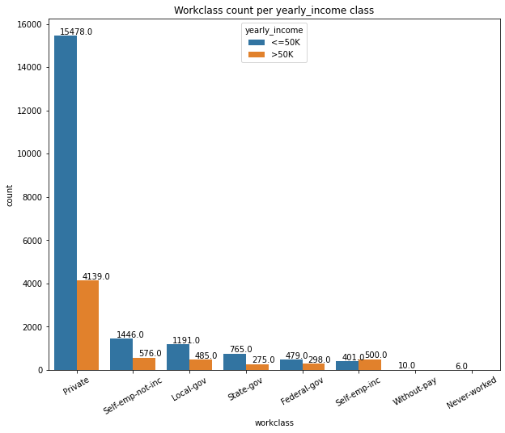

```python
sns_countplot('workclass', 'yearly_income', df, 'Workclass count per yearly_income class', 'vertical')
```

```python
round(df.groupby('workclass')['target'].value_counts()/len(df)*100,2).sort_values(ascending=False)
```

```
workclass         target
Private           0         59.42
                  1         15.89
Self-emp-not-inc  0          5.55
Local-gov         0          4.57
State-gov         0          2.94
Self-emp-not-inc  1          2.21
Self-emp-inc      1          1.92
Local-gov         1          1.86
Federal-gov       0          1.84
Self-emp-inc      0          1.54
Federal-gov       1          1.14
State-gov         1          1.06
Without-pay       0          0.04
Never-worked      0          0.02
Name: target, dtype: float64
```

#### Observation: Private workclass label -> ~60% of employees earn <=50K. (target= 0) Self-emp-inc only label where employees earning >50K are more than emloyees earning <=50K.

#### Chi square test we will use target column which is just integer encoding on yearly_income column :

1) Make a contingency table by taking a sample of the population 2) State the null hypothesis and alternative hypothesis 3) Cacluate the Chi square test

```python
c_t = c_table('workclass', 'target')
c_t
```

| target workclass | 0 | 1 |
| --- | --- | --- |
| Federal-gov | 1 | 0 |
| Local-gov | 4 | 1 |
| Private | 28 | 8 |
| Self-emp-not-inc | 7 | 0 |
| State-gov | 2 | 1 |

#### H0(Null Hypothesis) : There is no relationship between workclass and target. H1(Alternate Hypothesis) : There is a relationship between workclass and target.

```python
chi_test(c_t)
```

```
dof=4
p_value 0.6449579502930338
[[ 0.80769231  0.19230769]
 [ 4.03846154  0.96153846]
 [29.07692308  6.92307692]
 [ 5.65384615  1.34615385]
 [ 2.42307692  0.57692308]]
probability=0.950, critical=9.488, stat=2.498
Independent (fail to reject H0)
```

#### Workclass not related to yearly_income? -> Conclusion: Yes, it is not related to the target column thus workclass has no dependency to target column aka yearly_income.

```python
df.columns
```

```
Index(['rowid', 'age', 'workclass', 'fnlwgt', 'education', 'education_num',
       'marital_status', 'occupation', 'relationship', 'race', 'sex',
       'capital_gain', 'capital_loss', 'hours_per_week', 'native_country',
       'yearly_income', 'age_range', 'education_level', 'country',
       'change_capital', 'target'],
      dtype='object')
```

### 4.4.2. Hypothesis Testing to test relationship between yearly_income and Education_level:

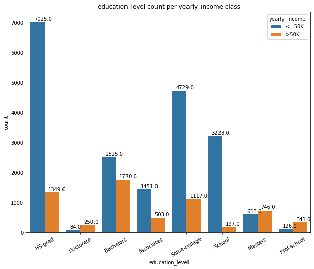

```python
sns_countplot('education_level', 'yearly_income', df, 'education_level count per yearly_income class', 'vertical')
```

```python
round(df.groupby('education_level')['target'].value_counts()/len(df)*100,2)
```

```
education_level  target
Associates       0          5.57
                 1          1.93
Bachelors        0          9.69
                 1          6.79
Doctorate        1          0.96
                 0          0.32
HS-grad          0         26.97
                 1          5.18
Masters          1          2.86
                 0          2.35
Prof-school      1          1.31
                 0          0.48
School           0         12.37
                 1          0.76
Some-college     0         18.15
                 1          4.29
Name: target, dtype: float64
```

#### Observation: Even though most of the employees are High School graduates, still only ~6% of employees are earning >50K yearly income (group 1) As per observation, Post graduate degree employees like Doctrates, Prof-School, Masters earn higher (group 1)

#### H0(Null Hypothesis) : There is no relationship between education_level and target. H1(Alternate Hypothesis) : There is a relationship between education_level and target.

```python
c_t = c_table('education_level', 'target')
c_t
```

| target education_level | 0 | 1 |
| --- | --- | --- |
| Associates | 4 | 0 |
| Bachelors | 8 | 5 |
| Doctorate | 1 | 1 |
| HS-grad | 12 | 1 |
| Masters | 0 | 1 |
| School | 6 | 0 |
| Some-college | 11 | 2 |

```python
chi_test(c_t)
```

```
dof=6
p_value 0.059059551129879304
[[ 3.23076923  0.76923077]
 [10.5         2.5       ]
 [ 1.61538462  0.38461538]
 [10.5         2.5       ]
 [ 0.80769231  0.19230769]
 [ 4.84615385  1.15384615]
 [10.5         2.5       ]]
probability=0.950, critical=12.592, stat=12.133
Independent (fail to reject H0)
```

#### Education_level influences yearly_income? -> Conclusion: No, it is not related to the target column thus education_level has no dependency to target column aka yearly_income.

### 4.4.3. Hypothesis testing to test relationship between target i.e yearly_column and relationship:

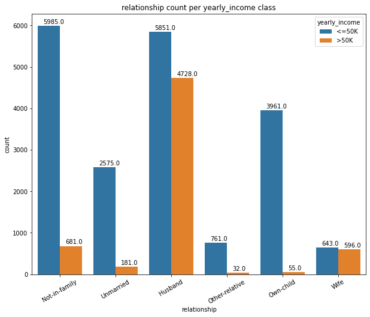

```python
sns_countplot('relationship', 'yearly_income', df, 'relationship count per yearly_income class', 'v')
```

```python
round(df.groupby('relationship')['target'].value_counts()/len(df)*100,2)
```

```
relationship    target
Husband         0         22.46
                1         18.15
Not-in-family   0         22.98
                1          2.61
Other-relative  0          2.92
                1          0.12
Own-child       0         15.21
                1          0.21
Unmarried       0          9.89
                1          0.69
Wife            0          2.47
                1          2.29
Name: target, dtype: float64
```

#### Observation: Husband label highest percentage(18.15%) of earning more than 50k in all the other categories. One thing to notice is that "not-in-family" has highest %(~23%) to earn less than 50k but they are nearly same %(2.61%) as of the wife label(2.29%) category.

```python
c_t = c_table('relationship', 'target')
c_t
```

| target relationship | 0 | 1 |
| --- | --- | --- |
| Husband | 14 | 8 |
| Not-in-family | 13 | 1 |
| Other-relative | 1 | 0 |
| Own-child | 8 | 0 |
| Unmarried | 5 | 0 |
| Wife | 1 | 1 |

```python
chi_test(c_t)
```

```
dof=5
p_value 0.07447484208515746
[[17.76923077  4.23076923]
 [11.30769231  2.69230769]
 [ 0.80769231  0.19230769]
 [ 6.46153846  1.53846154]
 [ 4.03846154  0.96153846]
 [ 1.61538462  0.38461538]]
probability=0.950, critical=11.070, stat=10.027
Independent (fail to reject H0)
```

#### Relationship influences yearly_income? -> Conclusion: No, it is not related to the target column thus relationship has no dependency some on target column aka yearly_income.

### 4.4.4. Hypothesis Testing to test relationship between yearly_income and Marital_status:

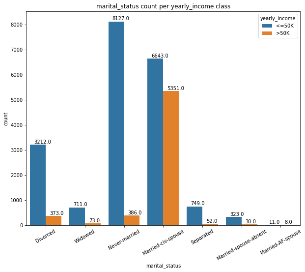

```python
sns_countplot('marital_status', 'yearly_income', df, 'marital_status count per yearly_income class', 'vertical')
```

```python
df.marital_status.value_counts()
```

```
Married-civ-spouse       11994
Never-married             8513
Divorced                  3585
Separated                  801
Widowed                    784
Married-spouse-absent      353
Married-AF-spouse           19
Name: marital_status, dtype: int64
```

```python
round(df.groupby('marital_status')['target'].value_counts()/len(df)*100,2)
```

```
marital_status         target
Divorced               0         12.33
                       1          1.43
Married-AF-spouse      0          0.04
                       1          0.03
Married-civ-spouse     0         25.50
                       1         20.54
Married-spouse-absent  0          1.24
                       1          0.12
Never-married          0         31.20
                       1          1.48
Separated              0          2.88
                       1          0.20
Widowed                0          2.73
                       1          0.28
Name: target, dtype: float64
```

#### Observation: Married-civ-spouse has the highest percentage(20.54%) of falling under the income group 1(>50k). Despite the fact that we have 8513 observations in the marital-status column(which is sec. highest) but only 1.48% of the people of "Never-married" earn more than 50k.

#### H0(Null Hypothesis) : There is no relationship between marital_status and target. H1(Alternate Hypothesis) : There is a relationship between marital_status and target.

```python
# contingency table
c_t = c_table('marital_status', 'target')
c_t
```

| target marital_status | 0 | 1 |
| --- | --- | --- |
| Divorced | 9 | 0 |
| Married-civ-spouse | 16 | 9 |
| Never-married | 16 | 1 |
| Separated | 1 | 0 |

```python
chi_test(c_t)
```

```
dof=3
p_value 0.0312511669906126
[[ 7.26923077  1.73076923]
 [20.19230769  4.80769231]
 [13.73076923  3.26923077]
 [ 0.80769231  0.19230769]]
probability=0.950, critical=7.815, stat=8.857
Dependent (reject H0)
```

#### Marital_status influences yearly_income? -> Conclusion: Yes, it is related to the target column thus marital_status has dependency to target column aka yearly_income.

### 4.4.5. Hypothesis Testing to test relationship between yearly_income and Occupation:

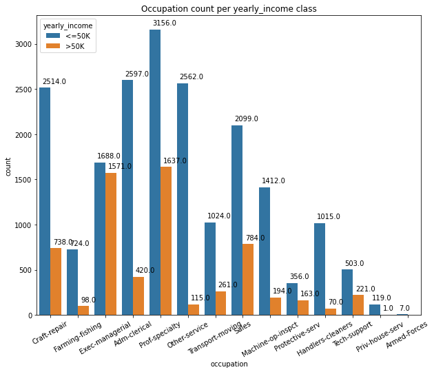

```python
sns_countplot('occupation', 'yearly_income', df, 'Occupation count per yearly_income class', 'vertical')
```

```python
df.occupation.value_counts()
```

```
Prof-specialty       4793
Exec-managerial      3259
Craft-repair         3252
Adm-clerical         3017
Sales                2883
Other-service        2677
Machine-op-inspct    1606
Transport-moving     1285
Handlers-cleaners    1085
Farming-fishing       822
Tech-support          724
Protective-serv       519
Priv-house-serv       120
Armed-Forces            7
Name: occupation, dtype: int64
```

```python
round(df.groupby('occupation')['target'].value_counts()/len(df)*100,2)
```

```
occupation         target
Adm-clerical       0          9.97
                   1          1.61
Armed-Forces       0          0.03
Craft-repair       0          9.65
                   1          2.83
Exec-managerial    0          6.48
                   1          6.03
Farming-fishing    0          2.78
                   1          0.38
Handlers-cleaners  0          3.90
                   1          0.27
Machine-op-inspct  0          5.42
                   1          0.74
Other-service      0          9.84
                   1          0.44
Priv-house-serv    0          0.46
                   1          0.00
Prof-specialty     0         12.12
                   1          6.28
Protective-serv    0          1.37
                   1          0.63
Sales              0          8.06
                   1          3.01
Tech-support       0          1.93
                   1          0.85
Transport-moving   0          3.93
                   1          1.00
Name: target, dtype: float64
```

#### Observation: Prof-specialty has maximum percentage that fall in both income group 0 and 1 in whole categories with 12.12% and 6.28% respectively.

#### H0(Null Hypothesis) : There is no relationship between occupation and target. H1(Alternate Hypothesis) : There is a relationship between occupation and target.

```python
# contingency table
c_t = c_table('occupation', 'target')
c_t
```

| target occupation | 0 | 1 |
| --- | --- | --- |
| Adm-clerical | 6 | 0 |
| Craft-repair | 7 | 0 |
| Exec-managerial | 3 | 4 |
| Farming-fishing | 4 | 0 |
| Handlers-cleaners | 1 | 1 |
| Machine-op-inspct | 3 | 0 |
| Other-service | 3 | 0 |
| Prof-specialty | 8 | 2 |
| Sales | 6 | 3 |
| Transport-moving | 1 | 0 |

```python
chi_test(c_t)
```

```
dof=9
p_value 0.10353492139853833
[[4.84615385 1.15384615]
 [5.65384615 1.34615385]
 [5.65384615 1.34615385]
 [3.23076923 0.76923077]
 [1.61538462 0.38461538]
 [2.42307692 0.57692308]
 [2.42307692 0.57692308]
 [8.07692308 1.92307692]
 [7.26923077 1.73076923]
 [0.80769231 0.19230769]]
probability=0.950, critical=16.919, stat=14.567
Independent (fail to reject H0)
```

#### Occupation influences yearly_income? -> Conclusion: No, it is not related to the target column thus Occupation has no dependency to target column aka yearly_income.

### 4.4.6. Hypothesis Testing to test relationship between yearly_income and Race:

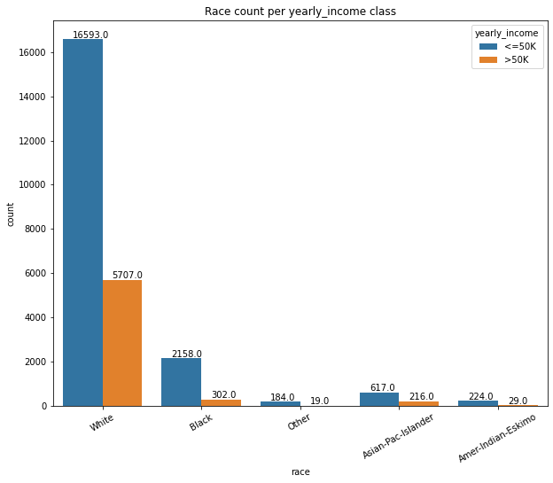

```python
sns_countplot('race', 'yearly_income', df, 'Race count per yearly_income class', 'vertical')
```

```python
df.race.value_counts()
```

```
White                 22300
Black                  2460
Asian-Pac-Islander      833
Amer-Indian-Eskimo      253
Other                   203
Name: race, dtype: int64
```

```python
round(df.groupby('race')['target'].value_counts()/len(df)*100,2)
```

```
race                target
Amer-Indian-Eskimo  0          0.86
                    1          0.11
Asian-Pac-Islander  0          2.37
                    1          0.83
Black               0          8.28
                    1          1.16
Other               0          0.71
                    1          0.07
White               0         63.70
                    1         21.91
Name: target, dtype: float64
```

#### H0(Null Hypothesis) : There is no relationship between race and target. H1(Alternate Hypothesis) : There is a relationship between race and target.

```python
# contingency table
c_t = c_table('race', 'target')
c_t
```

| target race | 0 | 1 |
| --- | --- | --- |
| Amer-Indian-Eskimo | 1 | 0 |
| Black | 6 | 1 |
| Other | 1 | 0 |
| White | 34 | 9 |

```python
chi_test(c_t)
```

```
dof=3
p_value 0.8810886884548982
[[ 0.80769231  0.19230769]
 [ 5.65384615  1.34615385]
 [ 0.80769231  0.19230769]
 [34.73076923  8.26923077]]
probability=0.950, critical=7.815, stat=0.666
Independent (fail to reject H0)
```

#### race influences yearly_income? -> Conclusion: No, it is not related to the target column thus race has no dependency to target column aka yearly_income.

### 4.4.7. Hypothesis Testing to test relationship between yearly_income and Sex:

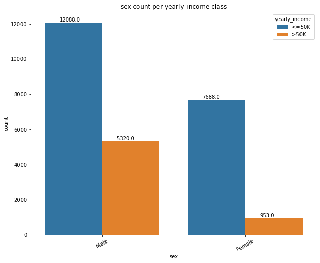

```python
sns_countplot('sex', 'yearly_income', df, 'sex count per yearly_income class', 'vertical')
```

```python
df.sex.value_counts()
```

```
Male      17408
Female     8641
Name: sex, dtype: int64
```

```python
round(df.groupby('sex')['target'].value_counts()/len(df)*100,2)
```

```
sex     target
Female  0         29.51
        1          3.66
Male    0         46.40
        1         20.42
Name: target, dtype: float64
```

#### Observation: For "female" earning more than 50k is rare with only 3.66% of all observations. But for male, 20.42% of all people earn more than 50k.

#### H0(Null Hypothesis) : There is no relationship between sex and target. H1(Alternate Hypothesis) : There is a relationship between sex and target.

```python
# contingency table
c_t = c_table('sex', 'target')
c_t
```

| target sex | 0 | 1 |
| --- | --- | --- |
| Female | 17 | 2 |
| Male | 25 | 8 |

```python
chi_test(c_t)
```

```
dof=1
p_value 0.3991557811677394
[[15.34615385  3.65384615]
 [26.65384615  6.34615385]]
probability=0.950, critical=3.841, stat=0.711
Independent (fail to reject H0)
```

#### Sex influences yearly_income? -> Conclusion: No, it is not related to the target column thus Sex has no dependency to target column aka yearly_income.

### 4.4.8. Hypothesis Testing to test relationship between yearly_income and Native_country:

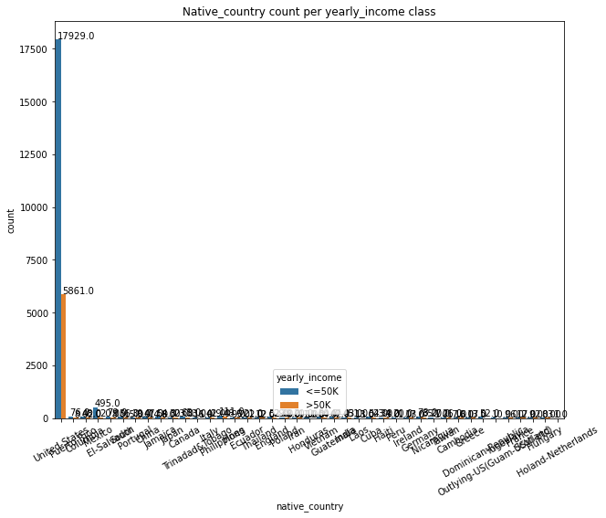

```python
sns_countplot('native_country', 'yearly_income', df, 'Native_country count per yearly_income class', 'vertical')
```

```python
df.native_country.value_counts()
```

```
United-States                 23790
Mexico                          515
Philippines                     159
Germany                         113
Canada                           98
El-Salvador                      87
Puerto-Rico                      84
England                          81
Cuba                             77
India                            76
South                            71
Jamaica                          62
China                            61
Italy                            61
Vietnam                          54
Japan                            53
Dominican-Republic               52
Columbia                         50
Guatemala                        49
Poland                           47
Taiwan                           43
Haiti                            37
Portugal                         33
Iran                             31
Nicaragua                        28
Ecuador                          23
Peru                             21
Greece                           20
Ireland                          20
France                           19
Trinadad&Tobago                  17
Cambodia                         16
Yugoslavia                       15
Hong                             14
Laos                             14
Thailand                         14
Honduras                         11
Scotland                         11
Hungary                          11
Outlying-US(Guam-USVI-etc)       10
Holand-Netherlands                1
Name: native_country, dtype: int64
```

```python
round(df.groupby('native_country')['target'].value_counts()/len(df)*100,2)
```

```
native_country  target
Cambodia        0          0.04
                1          0.02
Canada          0          0.25
                1          0.13
China           0          0.18
                          ...
United-States   1         22.50
Vietnam         0          0.19
                1          0.02
Yugoslavia      0          0.03
                1          0.02
Name: target, Length: 79, dtype: float64
```

#### H0(Null Hypothesis) : There is no relationship between native_country and target. H1(Alternate Hypothesis) : There is a relationship between native_country and target.

```python
# contingency table
c_t = c_table('native_country', 'target')
c_t
```

| target native_country | 0 | 1 |
| --- | --- | --- |
| England | 1 | 0 |
| Germany | 0 | 1 |
| Mexico | 3 | 0 |
| United-States | 38 | 9 |

```python
chi_test(c_t)
```

```
dof=3
p_value 0.16095916911416092
[[ 0.80769231  0.19230769]
 [ 0.80769231  0.19230769]
 [ 2.42307692  0.57692308]
 [37.96153846  9.03846154]]
probability=0.950, critical=7.815, stat=5.153
Independent (fail to reject H0)
```

#### native_country influences yearly_income? -> Conclusion: No, it is not related to the target column thus native_country has no dependency to target column aka yearly_income.

## 4.5 Multivariate Analysis to understand relationship of features with the target variable: back

```python
df.columns
```

```
Index(['rowid', 'age', 'workclass', 'fnlwgt', 'education', 'education_num',
       'marital_status', 'occupation', 'relationship', 'race', 'sex',
       'capital_gain', 'capital_loss', 'hours_per_week', 'native_country',
       'yearly_income', 'age_range', 'education_level', 'country',
       'change_capital', 'target'],
      dtype='object')
```

### 4.5.1. Between "yearly_income", "hours_per_week", "sex":

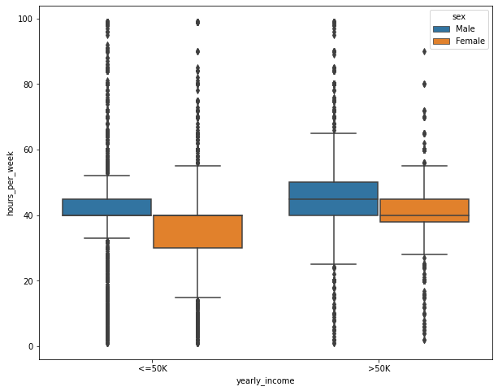

```python
plt.figure(figsize=(10,8))
splot = sns.boxplot(x='yearly_income',y ='hours_per_week', hue='sex',data=df, fliersize=5)
#splot.set(ylim=(0, 110))
plt.show()
```

### 4.5.2. Between "yearly_income", "age", "sex":

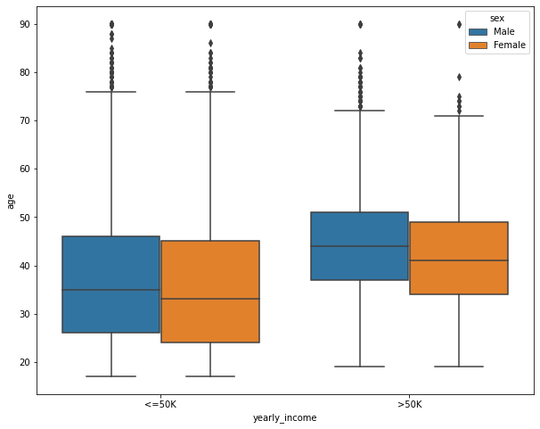

```python
plt.figure(figsize=(10,8))
splot = sns.boxplot(x='yearly_income',y ='age', hue='sex',data=df, fliersize=5)
#splot.set(ylim=(0, 110))
plt.show()
```

#### Observations: Median between Male and Female employees who earn <=50K is almost same. This is not the same for those employees who earn more than 50K though, Males seem to be elder than 1-5 years in this case.

### 4.5.3. Between 'yearly_income', 'age', 'occupation':

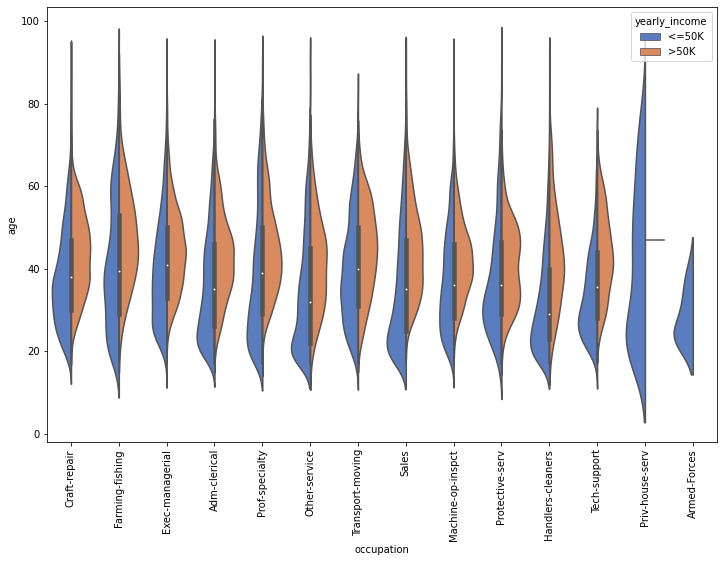

```python
plt.figure(figsize=(12,8))
splot = sns.violinplot(x="occupation", y="age", hue="yearly_income",
                    data=df, gridsize=100, palette="muted", split=True, saturation=0.75)
plt.xticks(None, None, rotation='vertical')
plt.show()
```

#### Observations: Private-house-service has all the age ranges covered but it is not high paying (it has almost noone earning >50K) Almost all the occupations have high salaries as employee age grows.